# Flights Dataset Data Visualization Project

## Investigation Overview

> The main goal of this project is to look into the various delay times within the 2007 Flight Dataset and find correlation with respect to the other variable

## Dataset Overview

> In this Project, we will be using Flights dataset taken from [Stats_Computing](http://stat-computing.org/dataexpo/2009/the-data.html). The Flights dataset essentially shows information of Flights from the US and includes data from 1987 to 2008. This rich data source contains so many variables for analysis including details pertaining to delays, flight information, causes of delays, taxi in/out, date etc. For my project, I am only including the analysis of the year 2007 since my system had touble encorporating all the data which surpasses to 1.5 GB.

```python
# import all packages and set plots to be embedded inline
import numpy as np
import pandas as pd
import matplotlib.pyplot as plt
import seaborn as sb

%matplotlib inline

# suppress warnings from final output
import warnings
warnings.simplefilter("ignore")
```

```python
# load in the dataset into a pandas dataframe
flights_2007_original = pd.read_csv('2007.csv')
flights_2007_original.isna().sum(), flights_2007_original.shape
flights_2007_original.drop_duplicates(inplace = True)
flights_2007_original.info()
flights_2007 = flights_2007_original.copy()
```

```
<class 'pandas.core.frame.DataFrame'>
Int64Index: 7453188 entries, 0 to 7453214
Data columns (total 29 columns):
 #   Column             Dtype
---  ------             -----
 0   Year               int64
 1   Month              int64
 2   DayofMonth         int64
 3   DayOfWeek          int64
 4   DepTime            float64
 5   CRSDepTime         int64
 6   ArrTime            float64
 7   CRSArrTime         int64
 8   UniqueCarrier      object
 9   FlightNum          int64
```

[output cut: 21 more lines]

## Worst Carrier

> In the Sub Slide is our 1st visualization which shows the carriers which showed the most delays throughout the year of 2007. Here we plot the departure delay time and arrival delay time with respect to the carriers and narrow down the worst 5 carriers.

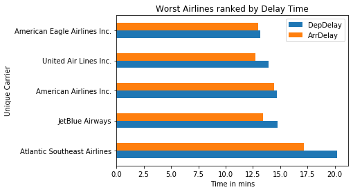

```python
carriers = pd.read_csv('carriers.csv')
carrier_dict = dict(carriers.values)

#plt.figure(figsize=([20, 15]));

flights_2007_worst = flights_2007.groupby('UniqueCarrier').agg({'DepDelay':'mean', 'ArrDelay':'mean'}).rename(index=carrier_dict).sort_values('DepDelay', ascending=False).head(5)

flights_2007_worst.plot(kind = 'barh');
plt.xlabel('Time in mins');
plt.ylabel('Unique Carrier');
plt.title('Worst Airlines ranked by Delay Time');
```

## Relation between Arrival Time Delay, Departure Time Delay and Elapsed Time Delay

> In this visualization, we found the correlation between the three different delays and concluded a strong correlation between arrival and departure delay time. Elapsed time delay was not considered to be a strong enough correlation.

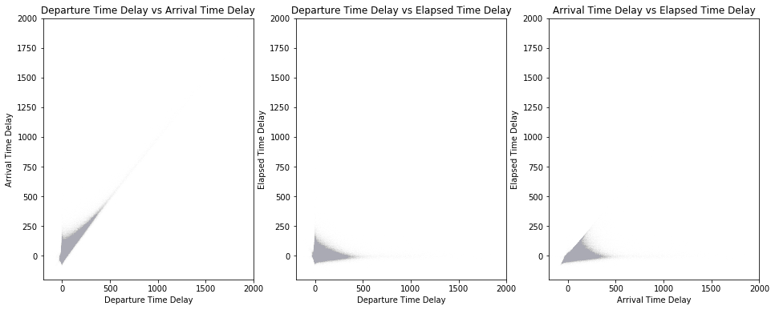

```python
fig, [ax1,ax2,ax3] = plt.subplots(1,3, figsize = [16,6])
sb.scatterplot(flights_2007.DepDelay, flights_2007.ArrDelay, alpha = 0.01,s = 0.3, ax = ax1)
ax1.set_xlabel('Departure Time Delay')
ax1.set_ylabel('Arrival Time Delay')
ax1.set_xlim([-200,2000])
ax1.set_ylim([-200,2000])
ax1.set_title('Departure Time Delay vs Arrival Time Delay')

sb.scatterplot(flights_2007.DepDelay, (flights_2007.ActualElapsedTime - flights_2007.CRSElapsedTime),s = 0.3, alpha = 0.01, ax = ax2)
ax2.set_xlabel('Departure Time Delay')
ax2.set_ylabel('Elapsed Time Delay')
ax2.set_xlim([-200,2000])
ax2.set_ylim([-200,2000])
ax2.set_title('Departure Time Delay vs Elapsed Time Delay')


sb.scatterplot(flights_2007.ArrDelay, (flights_2007.ActualElapsedTime - flights_2007.CRSElapsedTime),s = 0.3, alpha = 0.01, ax = ax3)
ax3.set_xlabel('Arrival Time Delay')
ax3.set_ylabel('Elapsed Time Delay')
ax3.set_xlim([-200,2000])
ax3.set_ylim([-200,2000])
ax3.set_title('Arrival Time Delay vs Elapsed Time Delay');
```

## Worst carriers in Terms of delay

> Here we try and find the worst carrier with respect to the delays. The Plot is pretty straightforward and gives us the 5 worst carriers with respect to delays in the year of 2007.

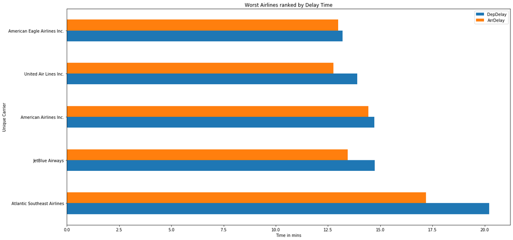

```python
carriers = pd.read_csv('carriers.csv')
carrier_dict = dict(carriers.values)

#plt.figure(figsize=([20, 15]));

flights_2007_worst = flights_2007.groupby('UniqueCarrier').agg({'DepDelay':'mean', 'ArrDelay':'mean'}).rename(index=carrier_dict).sort_values('DepDelay', ascending=False).head(5)

flights_2007_worst.plot(kind = 'barh', figsize=(20, 10));
plt.xlabel('Time in mins');
plt.ylabel('Unique Carrier');
plt.title('Worst Airlines ranked by Delay Time');
```

## Time Delays by Month

> We we plot the time delays vs month so as to see the best time to travel in 2007.Here we can see the best month to travel where the mean delays are much less than the rest of the year. Further analysis needs to be done on all the years to see if this pattern is consistent throughout. We will also need to see city by city calculation to know more about this pattern

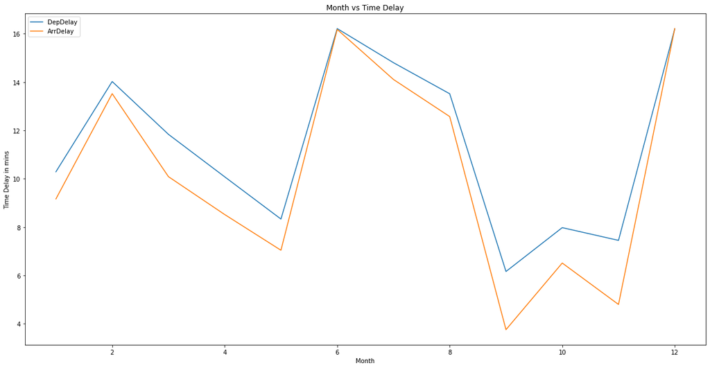

```python
flights_2007_mean = flights_2007.groupby('Month').agg({'DepDelay':'mean', 'ArrDelay':'mean'})


flights_2007_mean.plot.line(figsize=(20, 10));
plt.ylabel('Time Delay in mins');
plt.title('Month vs Time Delay');

plt.show();
```

## Line Plot comparing the various causes of delays in each month

> Here we compare the various types of delays for every month of the year 2007. Here we can see that the 2 main reasons for Delays are the Weather and also the Late Arrival of the plane. It is also interesting to note the variation of these delays does differ month to month drastically.

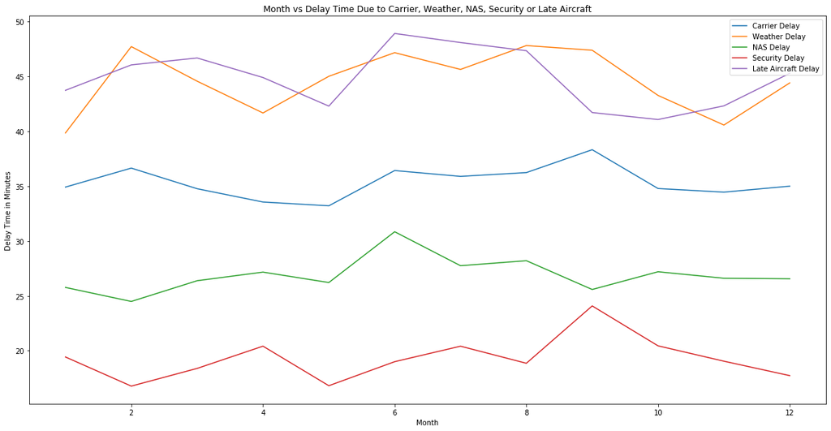

```python
Carrier_month = flights_2007.query('CarrierDelay > 0').groupby('Month').agg({'CarrierDelay':'mean'})
Weather_month = flights_2007.query('WeatherDelay > 0').groupby('Month').agg({'WeatherDelay':'mean'})
NASDelay_month = flights_2007.query('NASDelay > 0').groupby('Month').agg({'NASDelay':'mean'})
Security_month = flights_2007.query('SecurityDelay > 0').groupby('Month').agg({'SecurityDelay':'mean'})
LateAircraft_month = flights_2007.query('LateAircraftDelay >0').groupby('Month').agg({'LateAircraftDelay':'mean'})

plt.figure(figsize=[20,10])

plt.errorbar(x = Carrier_month.index, y = Carrier_month['CarrierDelay'])
plt.errorbar(x = Weather_month.index, y = Weather_month['WeatherDelay'])
plt.errorbar(x = NASDelay_month.index, y = NASDelay_month['NASDelay'])
plt.errorbar(x = Security_month.index, y = Security_month['SecurityDelay'])
plt.errorbar(x = LateAircraft_month.index, y = LateAircraft_month['LateAircraftDelay'])

plt.xlabel('Month')
plt.ylabel('Delay Time in Minutes')
plt.title('Month vs Delay Time Due to Carrier, Weather, NAS, Security or Late Aircraft')
plt.legend(['Carrier Delay', 'Weather Delay', 'NAS Delay', 'Security Delay', 'Late Aircraft Delay'])

plt.show()
```

## Line Plot comparing the various causes of delays with respect to the worst performing carriers

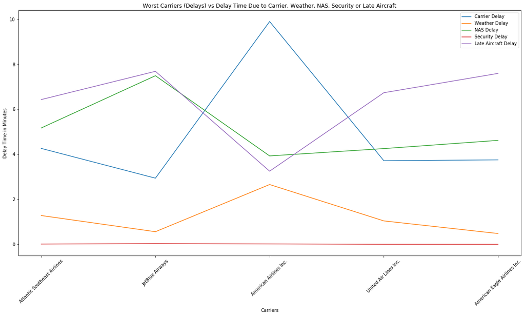

```python
#Subsetting the required data
flights_2007_worst1 = flights_2007.groupby('UniqueCarrier').agg({'DepDelay':'mean', 'ArrDelay':'mean'}).sort_values('DepDelay', ascending=False).head(5)
worst = pd.DataFrame(flights_2007_worst1.reset_index().UniqueCarrier)
worst1 = flights_2007.loc[flights_2007['UniqueCarrier'].isin(worst['UniqueCarrier'])]
flights_2007_worst.head(5).index

#grouping careerwise
carrier1 = worst1.groupby('UniqueCarrier').agg({'CarrierDelay':'mean'})
weather1 = worst1.groupby('UniqueCarrier').agg({'WeatherDelay':'mean'})
nas1 = worst1.groupby('UniqueCarrier').agg({'NASDelay':'mean'})
security1 = worst1.groupby('UniqueCarrier').agg({'SecurityDelay':'mean'})
late1 = worst1.groupby('UniqueCarrier').agg({'LateAircraftDelay':'mean'})

#PLotting the figure
plt.figure(figsize=[20,10])

plt.errorbar(x = carrier1.index, y = carrier1['CarrierDelay'])
plt.errorbar(x = weather1.index, y = weather1['WeatherDelay'])
plt.errorbar(x = nas1.index, y = nas1['NASDelay'])
plt.errorbar(x = security1.index, y = security1['SecurityDelay'])
plt.errorbar(x = late1.index, y = late1['LateAircraftDelay'])

plt.xlabel('Carriers')
plt.ylabel('Delay Time in Minutes')
plt.title('Worst Carriers (Delays) vs Delay Time Due to Carrier, Weather, NAS, Security or Late Aircraft')
plt.legend(['Carrier Delay', 'Weather Delay', 'NAS Delay', 'Security Delay', 'Late Aircraft Delay'])
plt.xticks(carrier1.index, labels =flights_2007_worst.head(5).index, rotation = 45)

plt.show()
```